# Risk Factor Analysis

## Outcome Variable

**Outcome Variable:** ever_stunted

## Predictor Variables

**Intervention Variable:** mwtkg

**Adjustment Set:**

unadjusted

## Stratifying Variables

The analysis was stratified on these variable(s):

- agecat
- studyid

The following strata were considered:

- agecat: 12 months, studyid: ki0047075b-MAL-ED
- agecat: 12 months, studyid: ki1017093-NIH-Birth
- agecat: 12 months, studyid: ki1017093b-PROVIDE
- agecat: 12 months, studyid: ki1017093c-NIH-Crypto
- agecat: 12 months, studyid: ki1066203-TanzaniaChild2
- agecat: 12 months, studyid: ki1126311-ZVITAMBO
- agecat: 12 months, studyid: ki1148112-LCNI-5
- agecat: 18 months, studyid: ki0047075b-MAL-ED
- agecat: 18 months, studyid: ki1017093-NIH-Birth
- agecat: 18 months, studyid: ki1017093b-PROVIDE
- agecat: 18 months, studyid: ki1017093c-NIH-Crypto
- agecat: 18 months, studyid: ki1066203-TanzaniaChild2
- agecat: 18 months, studyid: ki1126311-ZVITAMBO
- agecat: 18 months, studyid: ki1148112-LCNI-5
- agecat: 24 months, studyid: ki0047075b-MAL-ED
- agecat: 24 months, studyid: ki1017093-NIH-Birth
- agecat: 24 months, studyid: ki1017093b-PROVIDE
- agecat: 24 months, studyid: ki1017093c-NIH-Crypto
- agecat: 24 months, studyid: ki1066203-TanzaniaChild2
- agecat: 24 months, studyid: ki1126311-ZVITAMBO
- agecat: 24 months, studyid: ki1148112-LCNI-5
- agecat: 3 months, studyid: ki0047075b-MAL-ED
- agecat: 3 months, studyid: ki1017093-NIH-Birth
- agecat: 3 months, studyid: ki1017093b-PROVIDE
- agecat: 3 months, studyid: ki1017093c-NIH-Crypto
- agecat: 3 months, studyid: ki1066203-TanzaniaChild2
- agecat: 3 months, studyid: ki1126311-ZVITAMBO
- agecat: 6 months, studyid: ki0047075b-MAL-ED
- agecat: 6 months, studyid: ki1017093-NIH-Birth
- agecat: 6 months, studyid: ki1017093b-PROVIDE
- agecat: 6 months, studyid: ki1017093c-NIH-Crypto
- agecat: 6 months, studyid: ki1066203-TanzaniaChild2
- agecat: 6 months, studyid: ki1126311-ZVITAMBO
- agecat: 6 months, studyid: ki1148112-LCNI-5

### Dropped Strata

Some strata were dropped due to rare outcomes:

- agecat: 3 months, studyid: ki1017093b-PROVIDE
- agecat: 3 months, studyid: ki1066203-TanzaniaChild2
- agecat: 6 months, studyid: ki1017093b-PROVIDE
- agecat: 6 months, studyid: ki1066203-TanzaniaChild2
- agecat: 6 months, studyid: ki1148112-LCNI-5
- agecat: 12 months, studyid: ki1017093b-PROVIDE
- agecat: 12 months, studyid: ki1066203-TanzaniaChild2
- agecat: 18 months, studyid: ki1066203-TanzaniaChild2
- agecat: 18 months, studyid: ki1126311-ZVITAMBO
- agecat: 18 months, studyid: ki1148112-LCNI-5
- agecat: 24 months, studyid: ki1066203-TanzaniaChild2
- agecat: 24 months, studyid: ki1126311-ZVITAMBO
- agecat: 24 months, studyid: ki1148112-LCNI-5

## Methods Detail

We’re interested in the causal parameters $E[Y_a]$ for all values of $a \in \mathcal{A}$. These parameters represent the mean outcome if, possibly contrary to fact, we intervened to set all units to have $A=a$. Under the randomization and positivity assumptions, these are identified by the statistical parameters $\psi_a=E_W[E_{Y|A,W}(Y|A=a,W)]$. In addition, we’re interested in the mean of $Y$, $E[Y]$ under no intervention (the observed mean). We will estimate these parameters by using SuperLearner to fit the relevant likelihood factors – $E_{Y|A,W}(Y|A=a,W)$ and $p(A=a|W)$, and then updating our likelihood fit using a joint TMLE.

For unadjusted analyses ($W=\{\}$), initial likelihoods were estimated using Lrnr_glm to estimate the simple $E(Y|A)$ and Lrnr_mean to estimate $p(A)$. For adjusted analyses, a small library containing Lrnr_glmnet, Lrnr_xgboost, and Lrnr_mean was used.

Having estimated these parameters, we will then use the delta method to estimate relative risks and attributable risks relative to a prespecified baseline level of $A$.

# Results Detail

## Results Plots

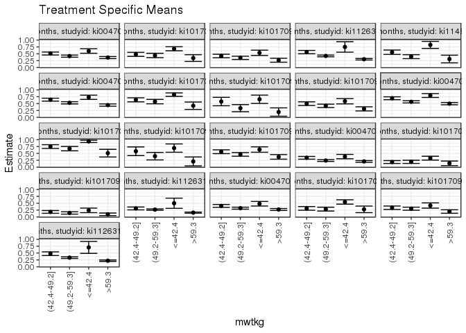

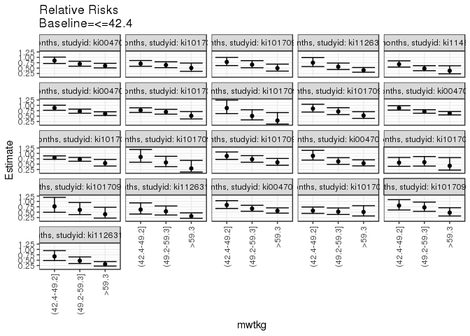

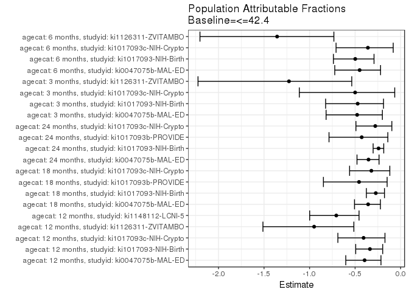

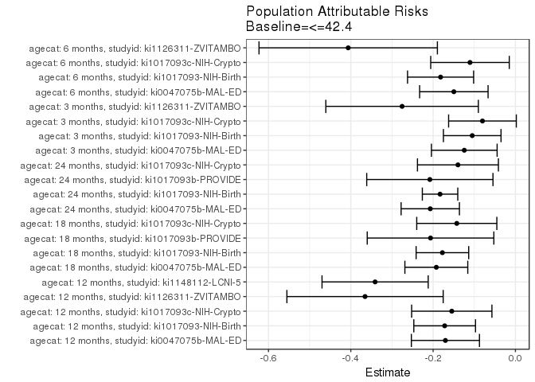

## Data Summary

| agecat | studyid | A | n | nA | nAY0 | nAY1 |
| --- | --- | --- | --- | --- | --- | --- |
| 3 months | ki0047075b-MAL-ED | <=42.4 | 1771 | 143 | 88 | 55 |
| 3 months | ki0047075b-MAL-ED | (42.4-49.2] | 1771 | 346 | 228 | 118 |
| 3 months | ki0047075b-MAL-ED | (49.2-59.3] | 1771 | 657 | 499 | 158 |
| 3 months | ki0047075b-MAL-ED | >59.3 | 1771 | 625 | 495 | 130 |
| 3 months | ki1017093-NIH-Birth | <=42.4 | 629 | 174 | 117 | 57 |
| 3 months | ki1017093-NIH-Birth | (42.4-49.2] | 629 | 209 | 170 | 39 |
| 3 months | ki1017093-NIH-Birth | (49.2-59.3] | 629 | 181 | 146 | 35 |
| 3 months | ki1017093-NIH-Birth | >59.3 | 629 | 65 | 56 | 9 |
| 3 months | ki1017093b-PROVIDE | <=42.4 | 171 | 42 | 26 | 16 |
| 3 months | ki1017093b-PROVIDE | (42.4-49.2] | 171 | 45 | 33 | 12 |
| 3 months | ki1017093b-PROVIDE | (49.2-59.3] | 171 | 58 | 46 | 12 |
| 3 months | ki1017093b-PROVIDE | >59.3 | 171 | 26 | 23 | 3 |
| 3 months | ki1017093c-NIH-Crypto | <=42.4 | 755 | 104 | 79 | 25 |
| 3 months | ki1017093c-NIH-Crypto | (42.4-49.2] | 755 | 228 | 186 | 42 |
| 3 months | ki1017093c-NIH-Crypto | (49.2-59.3] | 755 | 268 | 229 | 39 |
| 3 months | ki1017093c-NIH-Crypto | >59.3 | 755 | 155 | 140 | 15 |
| 3 months | ki1066203-TanzaniaChild2 | <=42.4 | 592 | 6 | 4 | 2 |
| 3 months | ki1066203-TanzaniaChild2 | (42.4-49.2] | 592 | 60 | 50 | 10 |
| 3 months | ki1066203-TanzaniaChild2 | (49.2-59.3] | 592 | 222 | 195 | 27 |
| 3 months | ki1066203-TanzaniaChild2 | >59.3 | 592 | 304 | 284 | 20 |
| 3 months | ki1126311-ZVITAMBO | <=42.4 | 2756 | 28 | 14 | 14 |
| 3 months | ki1126311-ZVITAMBO | (42.4-49.2] | 2756 | 306 | 211 | 95 |
| 3 months | ki1126311-ZVITAMBO | (49.2-59.3] | 2756 | 1157 | 846 | 311 |
| 3 months | ki1126311-ZVITAMBO | >59.3 | 2756 | 1265 | 1066 | 199 |
| 3 months | ki1148112-LCNI-5 | <=42.4 | 0 | 0 | 0 | 0 |
| 3 months | ki1148112-LCNI-5 | (42.4-49.2] | 0 | 0 | 0 | 0 |
| 3 months | ki1148112-LCNI-5 | (49.2-59.3] | 0 | 0 | 0 | 0 |
| 3 months | ki1148112-LCNI-5 | >59.3 | 0 | 0 | 0 | 0 |
| 6 months | ki0047075b-MAL-ED | <=42.4 | 1736 | 139 | 72 | 67 |
| 6 months | ki0047075b-MAL-ED | (42.4-49.2] | 1736 | 341 | 204 | 137 |

[output cut: 110 more lines]

## Results Table

### Parameter: TSM

| agecat | studyid | intervention_level | baseline_level | estimate | ci_lower | ci_upper |
| --- | --- | --- | --- | --- | --- | --- |
| 3 months | ki0047075b-MAL-ED | <=42.4 | NA | 0.3846154 | 0.3048546 | 0.4643762 |
| 3 months | ki0047075b-MAL-ED | (42.4-49.2] | NA | 0.3410405 | 0.2910756 | 0.3910054 |
| 3 months | ki0047075b-MAL-ED | (49.2-59.3] | NA | 0.2404871 | 0.2077981 | 0.2731761 |
| 3 months | ki0047075b-MAL-ED | >59.3 | NA | 0.2080000 | 0.1761709 | 0.2398291 |
| 3 months | ki1017093-NIH-Birth | <=42.4 | NA | 0.3275862 | 0.2577951 | 0.3973773 |
| 3 months | ki1017093-NIH-Birth | (42.4-49.2] | NA | 0.1866029 | 0.1337424 | 0.2394633 |
| 3 months | ki1017093-NIH-Birth | (49.2-59.3] | NA | 0.1933702 | 0.1357882 | 0.2509521 |
| 3 months | ki1017093-NIH-Birth | >59.3 | NA | 0.1384615 | 0.0544307 | 0.2224924 |
| 3 months | ki1017093c-NIH-Crypto | <=42.4 | NA | 0.2403846 | 0.1582040 | 0.3225652 |
| 3 months | ki1017093c-NIH-Crypto | (42.4-49.2] | NA | 0.1842105 | 0.1338588 | 0.2345623 |
| 3 months | ki1017093c-NIH-Crypto | (49.2-59.3] | NA | 0.1455224 | 0.1032766 | 0.1877682 |
| 3 months | ki1017093c-NIH-Crypto | >59.3 | NA | 0.0967742 | 0.0501997 | 0.1433487 |
| 3 months | ki1126311-ZVITAMBO | <=42.4 | NA | 0.5000000 | 0.3147672 | 0.6852328 |
| 3 months | ki1126311-ZVITAMBO | (42.4-49.2] | NA | 0.3104575 | 0.2586076 | 0.3623074 |
| 3 months | ki1126311-ZVITAMBO | (49.2-59.3] | NA | 0.2687986 | 0.2432485 | 0.2943487 |
| 3 months | ki1126311-ZVITAMBO | >59.3 | NA | 0.1573123 | 0.1372446 | 0.1773799 |
| 6 months | ki0047075b-MAL-ED | <=42.4 | NA | 0.4820144 | 0.3989233 | 0.5651055 |
| 6 months | ki0047075b-MAL-ED | (42.4-49.2] | NA | 0.4017595 | 0.3497100 | 0.4538091 |
| 6 months | ki0047075b-MAL-ED | (49.2-59.3] | NA | 0.3209302 | 0.2848926 | 0.3569678 |
| 6 months | ki0047075b-MAL-ED | >59.3 | NA | 0.2716858 | 0.2364044 | 0.3069671 |
| 6 months | ki1017093-NIH-Birth | <=42.4 | NA | 0.5466667 | 0.4669284 | 0.6264050 |
| 6 months | ki1017093-NIH-Birth | (42.4-49.2] | NA | 0.3118280 | 0.2451945 | 0.3784614 |
| 6 months | ki1017093-NIH-Birth | (49.2-59.3] | NA | 0.2857143 | 0.2158699 | 0.3555587 |
| 6 months | ki1017093-NIH-Birth | >59.3 | NA | 0.2777778 | 0.1582057 | 0.3973499 |
| 6 months | ki1017093c-NIH-Crypto | <=42.4 | NA | 0.4174757 | 0.3221748 | 0.5127767 |
| 6 months | ki1017093c-NIH-Crypto | (42.4-49.2] | NA | 0.3363229 | 0.2742721 | 0.3983737 |
| 6 months | ki1017093c-NIH-Crypto | (49.2-59.3] | NA | 0.3011583 | 0.2452495 | 0.3570671 |
| 6 months | ki1017093c-NIH-Crypto | >59.3 | NA | 0.1986755 | 0.1349914 | 0.2623596 |
| 6 months | ki1126311-ZVITAMBO | <=42.4 | NA | 0.7058824 | 0.4892354 | 0.9225293 |
| 6 months | ki1126311-ZVITAMBO | (42.4-49.2] | NA | 0.4768519 | 0.4102283 | 0.5434754 |

[output cut: 54 more lines]

### Parameter: E(Y)

| agecat | studyid | intervention_level | baseline_level | estimate | ci_lower | ci_upper |
| --- | --- | --- | --- | --- | --- | --- |
| 3 months | ki0047075b-MAL-ED | NA | NA | 0.2603049 | 0.2574972 | 0.2631127 |
| 3 months | ki1017093-NIH-Birth | NA | NA | 0.2225755 | 0.2173541 | 0.2277970 |
| 3 months | ki1017093c-NIH-Crypto | NA | NA | 0.1602649 | 0.1571032 | 0.1634266 |
| 3 months | ki1126311-ZVITAMBO | NA | NA | 0.2246009 | 0.2220995 | 0.2271023 |
| 6 months | ki0047075b-MAL-ED | NA | NA | 0.3323733 | 0.3293664 | 0.3353802 |
| 6 months | ki1017093-NIH-Birth | NA | NA | 0.3647913 | 0.3554396 | 0.3741430 |
| 6 months | ki1017093c-NIH-Crypto | NA | NA | 0.3070652 | 0.3022763 | 0.3118541 |
| 6 months | ki1126311-ZVITAMBO | NA | NA | 0.2995761 | 0.2958208 | 0.3033313 |
| 12 months | ki0047075b-MAL-ED | NA | NA | 0.4298454 | 0.4263975 | 0.4332933 |
| 12 months | ki1017093-NIH-Birth | NA | NA | 0.5101664 | 0.5005674 | 0.5197653 |
| 12 months | ki1017093c-NIH-Crypto | NA | NA | 0.3799726 | 0.3739934 | 0.3859517 |
| 12 months | ki1126311-ZVITAMBO | NA | NA | 0.3845824 | 0.3808725 | 0.3882924 |
| 12 months | ki1148112-LCNI-5 | NA | NA | 0.4825871 | 0.4693263 | 0.4958478 |
| 18 months | ki0047075b-MAL-ED | NA | NA | 0.5385572 | 0.5341283 | 0.5429861 |
| 18 months | ki1017093-NIH-Birth | NA | NA | 0.6498994 | 0.6387964 | 0.6610024 |
| 18 months | ki1017093b-PROVIDE | NA | NA | 0.4516129 | 0.4241466 | 0.4790792 |
| 18 months | ki1017093c-NIH-Crypto | NA | NA | 0.4433566 | 0.4369345 | 0.4497788 |
| 24 months | ki0047075b-MAL-ED | NA | NA | 0.5867014 | 0.5820327 | 0.5913701 |
| 24 months | ki1017093-NIH-Birth | NA | NA | 0.7553191 | 0.7433651 | 0.7672732 |
| 24 months | ki1017093b-PROVIDE | NA | NA | 0.4864865 | 0.4595391 | 0.5134339 |
| 24 months | ki1017093c-NIH-Crypto | NA | NA | 0.5015773 | 0.4947218 | 0.5084328 |

### Parameter: RR

| agecat | studyid | intervention_level | baseline_level | estimate | ci_lower | ci_upper |
| --- | --- | --- | --- | --- | --- | --- |
| 3 months | ki0047075b-MAL-ED | (42.4-49.2] | <=42.4 | 0.8867052 | 0.6878722 | 1.1430119 |
| 3 months | ki0047075b-MAL-ED | (49.2-59.3] | <=42.4 | 0.6252664 | 0.4879543 | 0.8012185 |
| 3 months | ki0047075b-MAL-ED | >59.3 | <=42.4 | 0.5408000 | 0.4179344 | 0.6997860 |
| 3 months | ki1017093-NIH-Birth | (42.4-49.2] | <=42.4 | 0.5696298 | 0.3996288 | 0.8119487 |
| 3 months | ki1017093-NIH-Birth | (49.2-59.3] | <=42.4 | 0.5902879 | 0.4093069 | 0.8512922 |
| 3 months | ki1017093-NIH-Birth | >59.3 | <=42.4 | 0.4226721 | 0.2221602 | 0.8041571 |
| 3 months | ki1017093c-NIH-Crypto | (42.4-49.2] | <=42.4 | 0.7663158 | 0.4946669 | 1.1871421 |
| 3 months | ki1017093c-NIH-Crypto | (49.2-59.3] | <=42.4 | 0.6053731 | 0.3865821 | 0.9479916 |
| 3 months | ki1017093c-NIH-Crypto | >59.3 | <=42.4 | 0.4025807 | 0.2230865 | 0.7264948 |
| 3 months | ki1126311-ZVITAMBO | (42.4-49.2] | <=42.4 | 0.6209150 | 0.4135685 | 0.9322168 |
| 3 months | ki1126311-ZVITAMBO | (49.2-59.3] | <=42.4 | 0.5375972 | 0.3667367 | 0.7880607 |
| 3 months | ki1126311-ZVITAMBO | >59.3 | <=42.4 | 0.3146245 | 0.2126327 | 0.4655378 |
| 6 months | ki0047075b-MAL-ED | (42.4-49.2] | <=42.4 | 0.8335011 | 0.6718238 | 1.0340868 |
| 6 months | ki0047075b-MAL-ED | (49.2-59.3] | <=42.4 | 0.6658105 | 0.5420044 | 0.8178967 |
| 6 months | ki0047075b-MAL-ED | >59.3 | <=42.4 | 0.5636466 | 0.4542301 | 0.6994197 |
| 6 months | ki1017093-NIH-Birth | (42.4-49.2] | <=42.4 | 0.5704170 | 0.4403827 | 0.7388472 |
| 6 months | ki1017093-NIH-Birth | (49.2-59.3] | <=42.4 | 0.5226481 | 0.3931703 | 0.6947651 |
| 6 months | ki1017093-NIH-Birth | >59.3 | <=42.4 | 0.5081301 | 0.3225429 | 0.8005017 |
| 6 months | ki1017093c-NIH-Crypto | (42.4-49.2] | <=42.4 | 0.8056106 | 0.6006942 | 1.0804307 |
| 6 months | ki1017093c-NIH-Crypto | (49.2-59.3] | <=42.4 | 0.7213792 | 0.5374992 | 0.9681650 |
| 6 months | ki1017093c-NIH-Crypto | >59.3 | <=42.4 | 0.4758971 | 0.3210766 | 0.7053707 |
| 6 months | ki1126311-ZVITAMBO | (42.4-49.2] | <=42.4 | 0.6755401 | 0.4821674 | 0.9464648 |
| 6 months | ki1126311-ZVITAMBO | (49.2-59.3] | <=42.4 | 0.4722222 | 0.3427827 | 0.6505399 |
| 6 months | ki1126311-ZVITAMBO | >59.3 | <=42.4 | 0.3143320 | 0.2262970 | 0.4366147 |
| 12 months | ki0047075b-MAL-ED | (42.4-49.2] | <=42.4 | 0.8486708 | 0.7129922 | 1.0101682 |
| 12 months | ki0047075b-MAL-ED | (49.2-59.3] | <=42.4 | 0.6922258 | 0.5862256 | 0.8173927 |
| 12 months | ki0047075b-MAL-ED | >59.3 | <=42.4 | 0.6050420 | 0.5083558 | 0.7201174 |
| 12 months | ki1017093-NIH-Birth | (42.4-49.2] | <=42.4 | 0.7043445 | 0.5839661 | 0.8495376 |
| 12 months | ki1017093-NIH-Birth | (49.2-59.3] | <=42.4 | 0.6419824 | 0.5203005 | 0.7921218 |
| 12 months | ki1017093-NIH-Birth | >59.3 | <=42.4 | 0.5055239 | 0.3486879 | 0.7329032 |
| 12 months | ki1017093c-NIH-Crypto | (42.4-49.2] | <=42.4 | 0.7835335 | 0.6168841 | 0.9952029 |
| 12 months | ki1017093c-NIH-Crypto | (49.2-59.3] | <=42.4 | 0.6601307 | 0.5158675 | 0.8447374 |
| 12 months | ki1017093c-NIH-Crypto | >59.3 | <=42.4 | 0.4954623 | 0.3589722 | 0.6838494 |
| 12 months | ki1126311-ZVITAMBO | (42.4-49.2] | <=42.4 | 0.7500000 | 0.5695726 | 0.9875826 |
| 12 months | ki1126311-ZVITAMBO | (49.2-59.3] | <=42.4 | 0.5624787 | 0.4321854 | 0.7320523 |
| 12 months | ki1126311-ZVITAMBO | >59.3 | <=42.4 | 0.4024691 | 0.3075893 | 0.5266159 |
| 12 months | ki1148112-LCNI-5 | (42.4-49.2] | <=42.4 | 0.6764142 | 0.5473510 | 0.8359100 |
| 12 months | ki1148112-LCNI-5 | (49.2-59.3] | <=42.4 | 0.4802260 | 0.3778152 | 0.6103963 |
| 12 months | ki1148112-LCNI-5 | >59.3 | <=42.4 | 0.3758503 | 0.2329553 | 0.6063975 |
| 18 months | ki0047075b-MAL-ED | (42.4-49.2] | <=42.4 | 0.8806243 | 0.7711845 | 1.0055948 |
| 18 months | ki0047075b-MAL-ED | (49.2-59.3] | <=42.4 | 0.7232427 | 0.6356972 | 0.8228445 |
| 18 months | ki0047075b-MAL-ED | >59.3 | <=42.4 | 0.6103400 | 0.5310918 | 0.7014134 |
| 18 months | ki1017093-NIH-Birth | (42.4-49.2] | <=42.4 | 0.7711923 | 0.6714638 | 0.8857329 |
| 18 months | ki1017093-NIH-Birth | (49.2-59.3] | <=42.4 | 0.6930982 | 0.5902451 | 0.8138740 |
| 18 months | ki1017093-NIH-Birth | >59.3 | <=42.4 | 0.5113712 | 0.3688595 | 0.7089436 |
| 18 months | ki1017093b-PROVIDE | (42.4-49.2] | <=42.4 | 0.8740000 | 0.6142752 | 1.2435403 |
| 18 months | ki1017093b-PROVIDE | (49.2-59.3] | <=42.4 | 0.5066667 | 0.3223380 | 0.7964034 |
| 18 months | ki1017093b-PROVIDE | >59.3 | <=42.4 | 0.2923077 | 0.1283440 | 0.6657403 |
| 18 months | ki1017093c-NIH-Crypto | (42.4-49.2] | <=42.4 | 0.8495513 | 0.6868517 | 1.0507907 |
| 18 months | ki1017093c-NIH-Crypto | (49.2-59.3] | <=42.4 | 0.7140404 | 0.5725393 | 0.8905131 |
| 18 months | ki1017093c-NIH-Crypto | >59.3 | <=42.4 | 0.5260983 | 0.3919761 | 0.7061129 |
| 24 months | ki0047075b-MAL-ED | (42.4-49.2] | <=42.4 | 0.8758033 | 0.7798652 | 0.9835435 |
| 24 months | ki0047075b-MAL-ED | (49.2-59.3] | <=42.4 | 0.7117895 | 0.6347388 | 0.7981933 |
| 24 months | ki0047075b-MAL-ED | >59.3 | <=42.4 | 0.6288180 | 0.5559460 | 0.7112420 |
| 24 months | ki1017093-NIH-Birth | (42.4-49.2] | <=42.4 | 0.7991803 | 0.7225252 | 0.8839681 |
| 24 months | ki1017093-NIH-Birth | (49.2-59.3] | <=42.4 | 0.7182757 | 0.6336110 | 0.8142534 |
| 24 months | ki1017093-NIH-Birth | >59.3 | <=42.4 | 0.5436601 | 0.4116532 | 0.7179983 |
| 24 months | ki1017093b-PROVIDE | (42.4-49.2] | <=42.4 | 0.8336842 | 0.5885050 | 1.1810084 |
| 24 months | ki1017093b-PROVIDE | (49.2-59.3] | <=42.4 | 0.5760000 | 0.3845239 | 0.8628229 |
| 24 months | ki1017093b-PROVIDE | >59.3 | <=42.4 | 0.3000000 | 0.1331666 | 0.6758453 |
| 24 months | ki1017093c-NIH-Crypto | (42.4-49.2] | <=42.4 | 0.8751297 | 0.7187767 | 1.0654937 |
| 24 months | ki1017093c-NIH-Crypto | (49.2-59.3] | <=42.4 | 0.7252661 | 0.5880697 | 0.8944702 |
| 24 months | ki1017093c-NIH-Crypto | >59.3 | <=42.4 | 0.5832579 | 0.4455428 | 0.7635399 |

### Parameter: PAR

| agecat | studyid | intervention_level | baseline_level | estimate | ci_lower | ci_upper |
| --- | --- | --- | --- | --- | --- | --- |
| 3 months | ki0047075b-MAL-ED | <=42.4 | NA | -0.1243105 | -0.2041207 | -0.0445003 |
| 3 months | ki1017093-NIH-Birth | <=42.4 | NA | -0.1050107 | -0.1749968 | -0.0350245 |
| 3 months | ki1017093c-NIH-Crypto | <=42.4 | NA | -0.0801197 | -0.1623611 | 0.0021217 |
| 3 months | ki1126311-ZVITAMBO | <=42.4 | NA | -0.2753991 | -0.4606488 | -0.0901494 |
| 6 months | ki0047075b-MAL-ED | <=42.4 | NA | -0.1496411 | -0.2327866 | -0.0664956 |
| 6 months | ki1017093-NIH-Birth | <=42.4 | NA | -0.1818754 | -0.2621602 | -0.1015906 |
| 6 months | ki1017093c-NIH-Crypto | <=42.4 | NA | -0.1104105 | -0.2058317 | -0.0149893 |
| 6 months | ki1126311-ZVITAMBO | <=42.4 | NA | -0.4063063 | -0.6229858 | -0.1896268 |
| 12 months | ki0047075b-MAL-ED | <=42.4 | NA | -0.1701546 | -0.2528904 | -0.0874188 |
| 12 months | ki1017093-NIH-Birth | <=42.4 | NA | -0.1719528 | -0.2469102 | -0.0969955 |
| 12 months | ki1017093c-NIH-Crypto | <=42.4 | NA | -0.1546809 | -0.2522085 | -0.0571533 |
| 12 months | ki1126311-ZVITAMBO | <=42.4 | NA | -0.3654176 | -0.5552672 | -0.1755680 |
| 12 months | ki1148112-LCNI-5 | <=42.4 | NA | -0.3409423 | -0.4699254 | -0.2119593 |
| 18 months | ki0047075b-MAL-ED | <=42.4 | NA | -0.1922120 | -0.2686123 | -0.1158117 |
| 18 months | ki1017093-NIH-Birth | <=42.4 | NA | -0.1774387 | -0.2413065 | -0.1135710 |
| 18 months | ki1017093b-PROVIDE | <=42.4 | NA | -0.2062818 | -0.3600824 | -0.0524812 |
| 18 months | ki1017093c-NIH-Crypto | <=42.4 | NA | -0.1425019 | -0.2398109 | -0.0451929 |
| 24 months | ki0047075b-MAL-ED | <=42.4 | NA | -0.2069494 | -0.2777873 | -0.1361114 |
| 24 months | ki1017093-NIH-Birth | <=42.4 | NA | -0.1831424 | -0.2261898 | -0.1400950 |
| 24 months | ki1017093b-PROVIDE | <=42.4 | NA | -0.2079580 | -0.3613285 | -0.0545874 |
| 24 months | ki1017093c-NIH-Crypto | <=42.4 | NA | -0.1397271 | -0.2380490 | -0.0414051 |

### Parameter: PAF

| agecat | studyid | intervention_level | baseline_level | estimate | ci_lower | ci_upper |
| --- | --- | --- | --- | --- | --- | --- |
| 3 months | ki0047075b-MAL-ED | <=42.4 | NA | -0.4775572 | -0.8185664 | -0.2004924 |
| 3 months | ki1017093-NIH-Birth | <=42.4 | NA | -0.4717980 | -0.8236118 | -0.1878567 |
| 3 months | ki1017093c-NIH-Crypto | <=42.4 | NA | -0.4999205 | -1.1124581 | -0.0649970 |
| 3 months | ki1126311-ZVITAMBO | <=42.4 | NA | -1.2261712 | -2.2249458 | -0.5367199 |
| 6 months | ki0047075b-MAL-ED | <=42.4 | NA | -0.4502201 | -0.7234630 | -0.2202979 |
| 6 months | ki1017093-NIH-Birth | <=42.4 | NA | -0.4985738 | -0.7377866 | -0.2922895 |
| 6 months | ki1017093c-NIH-Crypto | <=42.4 | NA | -0.3595670 | -0.7091180 | -0.0815066 |
| 6 months | ki1126311-ZVITAMBO | <=42.4 | NA | -1.3562708 | -2.2035278 | -0.7330932 |
| 12 months | ki0047075b-MAL-ED | <=42.4 | NA | -0.3958506 | -0.6024128 | -0.2159158 |
| 12 months | ki1017093-NIH-Birth | <=42.4 | NA | -0.3370525 | -0.4934128 | -0.1970631 |
| 12 months | ki1017093c-NIH-Crypto | <=42.4 | NA | -0.4070844 | -0.6892221 | -0.1720700 |
| 12 months | ki1126311-ZVITAMBO | <=42.4 | NA | -0.9501670 | -1.5122613 | -0.5138359 |
| 12 months | ki1148112-LCNI-5 | <=42.4 | NA | -0.7064888 | -0.9989759 | -0.4567979 |
| 18 months | ki0047075b-MAL-ED | <=42.4 | NA | -0.3569018 | -0.5066662 | -0.2220241 |
| 18 months | ki1017093-NIH-Birth | <=42.4 | NA | -0.2730249 | -0.3761822 | -0.1776002 |
| 18 months | ki1017093b-PROVIDE | <=42.4 | NA | -0.4567669 | -0.8480720 | -0.1483156 |
| 18 months | ki1017093c-NIH-Crypto | <=42.4 | NA | -0.3214161 | -0.5605994 | -0.1188908 |
| 24 months | ki0047075b-MAL-ED | <=42.4 | NA | -0.3527337 | -0.4792630 | -0.2370271 |
| 24 months | ki1017093-NIH-Birth | <=42.4 | NA | -0.2424702 | -0.3020285 | -0.1856363 |
| 24 months | ki1017093b-PROVIDE | <=42.4 | NA | -0.4274691 | -0.7865139 | -0.1405834 |
| 24 months | ki1017093c-NIH-Crypto | <=42.4 | NA | -0.2785753 | -0.4907783 | -0.0965781 |